# Copy of AIML_Project2

## Problem Statement

### Context

AllLife Bank is a US bank that has a growing customer base. The majority of these customers are liability customers (depositors) with varying sizes of deposits. The number of customers who are also borrowers (asset customers) is quite small, and the bank is interested in expanding this base rapidly to bring in more loan business and in the process, earn more through the interest on loans. In particular, the management wants to explore ways of converting its liability customers to personal loan customers (while retaining them as depositors).

A campaign that the bank ran last year for liability customers showed a healthy conversion rate of over 9% success. This has encouraged the retail marketing department to devise campaigns with better target marketing to increase the success ratio.

You as a Data scientist at AllLife bank have to build a model that will help the marketing department to identify the potential customers who have a higher probability of purchasing the loan.

### Objective

To predict whether a liability customer will buy personal loans, to understand which customer attributes are most significant in driving purchases, and identify which segment of customers to target more.

### Data Dictionary

- `ID`: Customer ID
- `Age`: Customer’s age in completed years
- `Experience`: #years of professional experience
- `Income`: Annual income of the customer (in thousand dollars)
- `ZIP Code`: Home Address ZIP code.
- `Family`: the Family size of the customer
- `CCAvg`: Average spending on credit cards per month (in thousand dollars)
- `Education`: Education Level. 1: Undergrad; 2: Graduate;3: Advanced/Professional
- `Mortgage`: Value of house mortgage if any. (in thousand dollars)
- `Personal_Loan`: Did this customer accept the personal loan offered in the last campaign? (0: No, 1: Yes)
- `Securities_Account`: Does the customer have securities account with the bank? (0: No, 1: Yes)
- `CD_Account`: Does the customer have a certificate of deposit (CD) account with the bank? (0: No, 1: Yes)
- `Online`: Do customers use internet banking facilities? (0: No, 1: Yes)
- `CreditCard`: Does the customer use a credit card issued by any other Bank (excluding All life Bank)? (0: No, 1: Yes)

## Importing necessary libraries

```python
# Installing the libraries with the specified version.
!pip install numpy==1.25.2 pandas==1.5.3 matplotlib==3.7.1 seaborn==0.13.1 scikit-learn==1.2.2 sklearn-pandas==2.2.0 -q --user
```

[output not shown]

**Note**:

1. After running the above cell, kindly restart the notebook kernel (for Jupyter Notebook) or runtime (for Google Colab), write the relevant code for the project from the next cell, and run all cells sequentially from the next cell.
2. On executing the above line of code, you might see a warning regarding package dependencies. This error message can be ignored as the above code ensures that all necessary libraries and their dependencies are maintained to successfully execute the code in this notebook.

```python
##Import Required Modules##
import pandas as pd
import numpy as np
import matplotlib.pyplot as plt
import seaborn as sns
import os
##Import Modules used for classification##
from sklearn.tree import DecisionTreeClassifier
from sklearn.model_selection import train_test_split
from sklearn.metrics import accuracy_score, confusion_matrix, classification_report, precision_score, recall_score, f1_score

##Import Modules used for clustering if required##
from sklearn.cluster import KMeans
from sklearn.metrics import silhouette_score
from sklearn.preprocessing import StandardScaler

##Silence warnings##
import warnings
warnings.filterwarnings('ignore')
```

```python
#from google.colab import drive
#drive.mount('/content/drive')
```

## Loading the dataset

```python
# uncomment and run the following lines for Google Colab
from google.colab import drive
drive.mount('/content/drive')


#print(os.listdir())


folder_path = '/content/drive/MyDrive/Python_DataSets'

dataset = 'Loan_Modelling.csv'

#filepath = os.path.join(folder_path, dataset)

#Output the first 5 rows#

df = pd.read_csv(os.path.join(folder_path, dataset))

#print(df.head())

print(df.head())


#print("Index:", df.index)

#print("Columns:", df.columns)

#df.head()

#print("Data Types:", df.info())

#print("# of Missing Values:", df.isnull().sum())


##Family- Represents the family size of the customers##
#fam_size_grouped = df.groupby('Family')['Mortgage'].value_counts(normalize=True)
#print(fam_size_grouped)

##CCAvg- Represents the average spending on credit cards per month##
#cc_avg_grouped = df.groupby('CCAvg')['Mortgage'].value_counts(normalize=True)
#print(cc_avg_grouped)


##Education- Represents how much education one has- Undergrad=1, Graduate=2, Advanced=3##
#education_grouped = df.groupby('Education')['Mortgage'].value_counts(normalize=True)

#print(education_grouped)


"""Analyze Zipcodes"""
##ZipCode- Need to determine how to handle these values##
#zipcode_freq = df['ZIPCode'].value_counts(normalize=True)

#print(zipcode_freq)

#Zipcode- Analyze by average income#
#zipcode_byincome = df.groupby('ZIPCode')['Income'].mean().sort_values(ascending=False)

#zipcode_byincome.sort_values('Income', ascending=False)

#print(zipcode_byincome)


#zipcodes_byattr = pd.DataFrame(df.groupby('ZIPCode')[['Experience', 'Income', 'CCAvg', 'Mortgage']].describe() )

#print(zipcodes_byattr)

##Create a new dataframe to analyze this further#
zipcode_df = df[['ZIPCode', 'Mortgage', 'CCAvg', 'Income', 'Experience']]

zipcode_df_avg = zipcode_df.groupby('ZIPCode').mean()

print(zipcode_df_avg)

##Minimum Income##
#print("Minimum Income:", zipcode_df['Income'].min())

##Median Income##
#print("Median Income:", zipcode_df['Income'].median() )

##Averge Income##
#print("Average Income:", zipcode_df['Income'].mean())

##Maximum Income##
#print("Max Income:", zipcode_df['Income'].max())


##Median Mortgage##
#print(zipcode_df['Mortgage'].median())

##Average Mortgage##
#print(zipcode_df['Mortgage'].mean())





####Compute a describe summary for each zipcode##

##Analyze credit card spend by zip code##
zipcode_descr_summary = df.groupby('ZIPCode')['Income'].describe()

#print("Income by Zip:", zipcode_descr_summary)


##Analyze for outliers by zipcode by standardizing the dataset##
##We want to observe how far each income value per zipcode is from the average##
##Less than 1 indicates lower than the average, More than 1 indicates greater than the average##

zipcode_df['ZipcodeIncome_AvgIncome_Ratio'] = zipcode_df.groupby('ZIPCode')['Income'].transform(lambda x: x/x.mean())

##Complete the same process to analyze outliers for the Credit Card Avg Variable##
zipcode_df['ZipcodeCCAvg_AvgCCAvg_Ratio'] = zipcode_df.groupby('ZIPCode')['CCAvg'].transform(lambda x: x/x.mean())

##Complete the same process to analyze outliers for the Mortgage Variable##
zipcode_df['ZipcodeMortgage_AvgMortgage_Ratio'] = zipcode_df.groupby('ZIPCode')['Mortgage'].transform(lambda x: x/x.mean())

##Filter the dataframe to show the outlier values from these buckets- income#

##~40-45% of all rows in the dataset include zipcodes that have higher incomes than the average across the dataset##
filtered_aboveavg_zipcodes = zipcode_df[zipcode_df['ZipcodeIncome_AvgIncome_Ratio'] > 1.0]


## Filter for high income zipcodes- income in the zipcode is 2x greater than the average across the dataset. ~383 rows in the dataset feature outlier-ish incomes##
filtered_HighIncome_zipcodes = zipcode_df[zipcode_df['ZipcodeIncome_AvgIncome_Ratio'] > 2.0]

print(filtered_HighIncome_zipcodes)

##5 Observations include incomes that are more than triple the average income##
filtered_extremeIncome_zipcodes = zipcode_df[zipcode_df['ZipcodeIncome_AvgIncome_Ratio'] > 3.0]

#print(filtered_extremeIncome_zipcodes)


##Filter the dataframe to show the outlier values from these buckets- Mortgage #



##Filter the dataframe to show the outlier from these buckets- CCAvg #
```

```
   ID  Age  Experience  Income  ZIPCode  Family  CCAvg  Education  Mortgage  \
0   1   25           1      49    91107       4    1.6          1         0
1   2   45          19      34    90089       3    1.5          1         0
2   3   39          15      11    94720       1    1.0          1         0
3   4   35           9     100    94112       1    2.7          2         0
4   5   35           8      45    91330       4    1.0          2         0

   Personal_Loan  Securities_Account  CD_Account  Online  CreditCard
0              0                   1           0       0           0
1              0                   1           0       0           0
2              0                   0           0       0           0
3              0                   0           0       0           0
4              0                   0           0       0           1
         Mortgage     CCAvg     Income  Experience
ZIPCode
```

[output cut: 53 more lines]

## Data Overview

- Observations- The average age of depositors is ~45 years old, with the youngest customer being 23 years old and the oldest customer being 67 years old. The average number of years of experience amongst customers is ~20 years, with 75% of the customers having at least 10 years of experience, and 25% of the customers having at least 30 years of experience.
- The average income amongst depositors is $73,774. This ranges from $8,000 to $224,000. 75% of customers made more than $39,000 annually, and 25% of customers made more than $98,000 annually. This indicates there may be some outliers to be found in the dataset for income
- Certain zip codes are clearly over-represented in our dataset, and are currently incorrectly categorized as a numerical variable, we therefore need to convert the numerical columns that should be categorical types to type 'category'
- Sanity checks- We observe certain columns need to be converted to type 'category'. We also observe there is a strong chance that we have outlier values within our experience, income, age, mortgage, and avg credit card spend per month group of variables.
- I was initially unsure how to handle the zip codes and my initial hunch was to remove them because in a real-life scenario this information probably can't be used for decision making due to potential ethical challenges and regulatory dilemmas. However, to make better sense of the information presented from the zip codes I created a seperate dataframe composed of just the field/column names, and added seperate columns for the ratio of income/mortgage/CCAvg in a given zipcode vs that of the average dataset to produce a more standardized measure that can be used for outlier detection. The results demonstrate that most zipcodes that have incomes that are below, at, or near the 1-2x the mean income, with very few rows in the dataset containing incomes at more than 3x.

```
<class 'pandas.core.frame.DataFrame'>
RangeIndex: 5000 entries, 0 to 4999
Data columns (total 14 columns):
 #   Column              Non-Null Count  Dtype
---  ------              --------------  -----
 0   ID                  5000 non-null   int64
 1   Age                 5000 non-null   int64
 2   Experience          5000 non-null   int64
 3   Income              5000 non-null   int64
 4   ZIPCode             5000 non-null   category
 5   Family              5000 non-null   int64
 6   CCAvg               5000 non-null   float64
 7   Education           5000 non-null   int64
 8   Mortgage            5000 non-null   int64
 9   Personal_Loan       5000 non-null   int64
 10  Securities_Account  5000 non-null   int64
 11  CD_Account          5000 non-null   int64
 12  Online              5000 non-null   int64
 13  CreditCard          5000 non-null   int64
dtypes: category(1), float64(1), int64(12)
memory usage: 537.5 KB
None
                ID          Age   Experience       Income       Family  \
count  5000.000000  5000.000000  5000.000000  5000.000000  5000.000000
mean   2500.500000    45.338400    20.104600    73.774200     2.396400
std    1443.520003    11.463166    11.467954    46.033729     1.147663
min       1.000000    23.000000    -3.000000     8.000000     1.000000
25%    1250.750000    35.000000    10.000000    39.000000     1.000000
50%    2500.500000    45.000000    20.000000    64.000000     2.000000
75%    3750.250000    55.000000    30.000000    98.000000     3.000000
max    5000.000000    67.000000    43.000000   224.000000     4.000000

             CCAvg    Education     Mortgage  Personal_Loan  \
count  5000.000000  5000.000000  5000.000000    5000.000000
mean      1.937938     1.881000    56.498800       0.096000
std       1.747659     0.839869   101.713802       0.294621
min       0.000000     1.000000     0.000000       0.000000
25%       0.700000     1.000000     0.000000       0.000000
50%       1.500000     2.000000     0.000000       0.000000
75%       2.500000     3.000000   101.000000       0.000000
```

[output cut: 19 more lines]

```
 3   Income              5000 non-null   int64
 4   ZIPCode             5000 non-null   category
 5   Family              5000 non-null   category
 6   CCAvg               5000 non-null   float64
 7   Education           5000 non-null   int64
 8   Mortgage            5000 non-null   int64
 9   Personal_Loan       5000 non-null   int64
 10  Securities_Account  5000 non-null   category
 11  CD_Account          5000 non-null   category
 12  Online              5000 non-null   category
 13  CreditCard          5000 non-null   category
dtypes: category(7), float64(1), int64(6)
memory usage: 334.5 KB
After Converting: None
56.4988
```

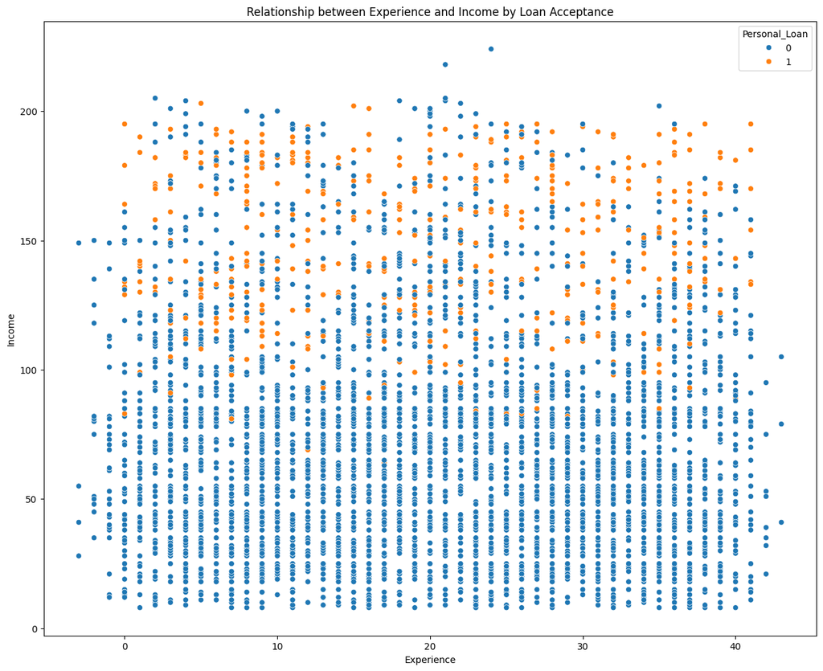

```python
##Sanity Checks##
print(df.info())


summarized_dataframe = df.describe()

print(summarized_dataframe)

#EDA Distribution of Personal Loan Interest based on Education#
personal_loan_count_by_education = df.groupby('Education')['Personal_Loan'].value_counts(normalize=True)
#print(personal_loan_count_by_education)

##EDA Distribution of Annual Income based on level of education##
#income_by_education = df.groupby('Education')['Income'].mean()


##EDA Distribution of Personal Loan Interest by Education Level##
#loan_count_byeducation = df.groupby('Education')['Personal_Loan'].sum()


"""Convert categorical variables to type categorical that were incorrectly categorized as type numbers initially"""

df['ZIPCode'] = df['ZIPCode'].astype('category')
df['Family'] = df['Family'].astype('category')
df['Age'] = df['Age'].astype('category')
df['CD_Account'] = df['CD_Account'].astype('category')
df['Online'] = df['Online'].astype('category')
df['CreditCard'] = df['CreditCard'].astype('category')
df['Securities_Account'] = df['Securities_Account'].astype('category')


print("After Converting:", df.info())



#print("Shape:", df.shape)


##EDA Distribution of Mortgage Attribute##
mortgage_counts = df['Mortgage'].value_counts()
mortgage_balances = df['Mortgage'].mean()
print(mortgage_balances)
#print(mortgage_counts)

#credit_card_counts = df['CreditCard'].value_counts()
#credit_card_percentage = df['CreditCard'].value_counts(normalize=True)

#print(credit_card_counts)
#print(credit_card_percentage)

#EDA Distribution of Personal Loan Interest based on Age#
#persoanl_loan_count_by_age = df.groupby('Age')['Personal_Loan'].value_counts(normalize=True)
#print(persoanl_loan_count_by_age)



##EDA Distribution of Mortgage Attribute##
#plt.figure(figsize=(15, 12));
#sns.boxplot(data = df, x='Education', y='Mortgage');
#plt.show()


##Evaluate outliers that may exist in our dataset##

plt.figure(figsize= (15, 12));
plt.title('Relationship between Experience and Income by Loan Acceptance')
sns.scatterplot(data = df, x='Experience', y='Income', hue='Personal_Loan');

plt.show()
```

## Exploratory Data Analysis.

- EDA is an important part of any project involving data.
- It is important to investigate and understand the data better before building a model with it.
- A few questions have been mentioned below which will help you approach the analysis in the right manner and generate insights from the data.
- A thorough analysis of the data, in addition to the questions mentioned below, should be done.

**Questions**:

Bachelor Degrees- 93/ (93 + 182 + 205) = 93/480 ~19.4% Masters Degrees- 182/(93 + 182 + 205) = 182/480 ~37.9% Advanced/Professional- 205/(93+182+205) = 205/480 ~42.7%

~80% of all customers who accepted the previous loan offer had either a Masters Degree or were categorized as Advanced/Professional. Only ~20% had a Bachelors Degree.

```
        ID Age  Experience  Income ZIPCode Family  CCAvg  Education  Mortgage  \
0        1  25           1      49   91107      4    1.6          1         0
1        2  45          19      34   90089      3    1.5          1         0
2        3  39          15      11   94720      1    1.0          1         0
3        4  35           9     100   94112      1    2.7          2         0
4        5  35           8      45   91330      4    1.0          2         0
...    ...  ..         ...     ...     ...    ...    ...        ...       ...
4995  4996  29           3      40   92697      1    1.9          3         0
4996  4997  30           4      15   92037      4    0.4          1        85
4997  4998  63          39      24   93023      2    0.3          3         0
4998  4999  65          40      49   90034      3    0.5          2         0
4999  5000  28           4      83   92612      3    0.8          1         0

      Personal_Loan Securities_Account CD_Account Online CreditCard
0                 0                  1          0      0          0
1                 0                  1          0      0          0
2                 0                  0          0      0          0
3                 0                  0          0      0          0
4                 0                  0          0      0          1
...             ...                ...        ...    ...        ...
4995              0                  0          0      1          0
4996              0                  0          0      1          0
4997              0                  0          0      0          0
4998              0                  0          0      1          0
4999              0                  0          0      1          1

[5000 rows x 14 columns]
```

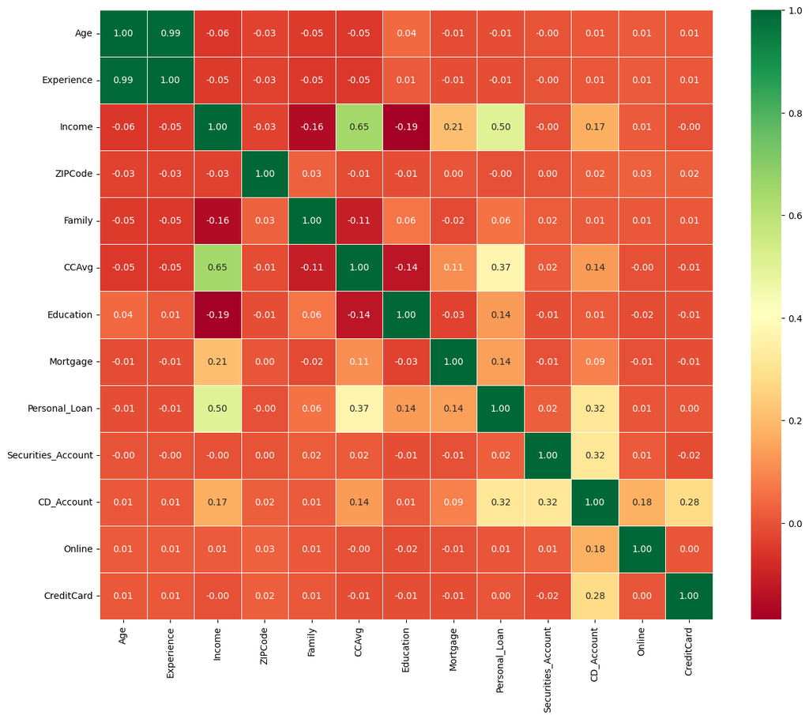

```
% of Insignificant Correlations: Age                   0.800198
Experience            0.799868
Income                0.783232
ZIPCode               1.000000
Family                0.858508
CCAvg                 0.789491
Education             0.852743
Mortgage              0.850107
Personal_Loan         0.861143
Securities_Account    0.915006
CD_Account            0.896228
Online                0.843354
CreditCard            0.858508
dtype: float64
```

```python
###Before Constructing the heatmap, we need to ensure we are only using the heatmap on numerical variables- Double check our dataframe##

#Select only the numerical data types from the data frame, then chain .columns to only select the column labels#
df_numerical_vars = df.select_dtypes(include=['int64', 'float64', 'category'])

print(df_numerical_vars)

#Remove the first column that shows the 'id'#
df_numerical_vars = df_numerical_vars.iloc[:, 1:].columns

##Create a plot figure##
plt.figure(figsize=(15,12));

#Analyze the correlation using a heatmap#
sns.heatmap(data= df[df_numerical_vars].corr(), annot=True, cmap='RdYlGn', fmt='.2f', linewidths=0.5);
plt.show()


"""Analyze the features by zipcode"""
##This is to determine whether zipcode has a meaningful signal or is mainly noise##
df_zipcode_corr = df.groupby('ZIPCode')[df_numerical_vars].corr()

"""Show average correlations amongst the columns"""
df_zipcode_avgcorr = df_zipcode_corr.mean()

"""View the statistical summary for the same correlations to understand them better"""
df_zipcode_corr.describe()


"""If only looking at correlations that have significance, do the results change?"""

##Filtered_correlations- filter out zip codes that don't have a correlation of at least 0.3##
df_zip_corr_filtered = df_zipcode_corr.map(lambda x: x if (x > 0.3) & (x != 1) else np.nan)

print("% of Insignificant Correlations:", df_zip_corr_filtered.isnull().sum()/len(df_zip_corr_filtered))

##Calculate Avg Correlations amongst the remaining columns that have at least weak correlations##
#print(df_zip_corr_filtered.describe())




#plt.figure(figsize=(15,12));
#sns.heatmap(data=df_numerical_vars.corr(), annot=True, cmap='RdYlGn', fmt='.2f', linewidths=0.5, mask=df_zip_corr_filtered.isna()    );
#plt.show()
```

## Data Preprocessing

- Analyzing the correlation heatmap a few things stand out- first, first we notice a strong correlation between Personal Loan acceptance and Income (0.50), and a strong correlation between Income and CCAvg as well (0.65), suggesting that Personal Loan acceptance should be driven by customers that have high incomes and high avg monthly spending on their credit cards (CCAvg).I also observed that there is a moderate correlation between Personal Loan Acceptance and CCAvg (0.37), and a relatively weak correlation between Income and Mortgage (0.21)- indicating those who have higher mortgage balances likely have higher incomes as well.

Missing value treatment- We did not spotlight any missing values, but we will need to figure out how to handle the zip codes correctly and encode them into our model. The biggest choice to consider is whether to drop zip code from our dataset before running the model, as it could be argued the column is primarily noise given that only ~20% of all zipcodes that significant relationships with other key explanatory variables, and thus the other ~80% might be adding significant noise.

- We added feature engineering to the dataset in 2 ways:
1. First- instead of dropping the zip codes, we are going to use them to build informative features that we can add to our model. From intuition, the goal is to encourage the model to select offer recipients that have higher incomes, higher Avg Credit Card spend, and lower mortgage balances, and we will create standardized ratios to measure this for each zipcode in our dataset. Next, we will need to see whether the original zipcodes and the newly created features are highly correlated if they are, we might need to consider dropping one of them- for regression this is crystal clear but for decision trees it is less so.
- Outlier detection and treatment (if needed)- Since all the observations represent "real" observations and there are no outliers due to data entry, we will make no changes here.
- Preparing data for modeling- Categorical features have already been encoded
- Any other preprocessing steps (if needed) - Choose Approach for Model Building given Desired End Goal

```
   ID Age  Experience  Income ZIPCode Family  CCAvg  Education  Mortgage  \
0   1  25           1    49.0   91107      4    1.6          1       0.0
1   2  45          19    34.0   90089      3    1.5          1       0.0
2   3  39          15    11.0   94720      1    1.0          1       0.0
3   4  35           9   100.0   94112      1    2.7          2       0.0
4   5  35           8    45.0   91330      4    1.0          2       0.0

   Personal_Loan Securities_Account CD_Account Online CreditCard  \
0              0                  1          0      0          0
1              0                  1          0      0          0
2              0                  0          0      0          0
3              0                  0          0      0          0
4              0                  0          0      0          1

   ZipCode_Income_Ratio  ZipCode_CCAvg_Ratio  ZipCode_Mortgage_Ratio
0              0.566081             0.819672                     0.0
1              0.408889             0.685885                     0.0
2              0.149293             0.531129                     0.0
3              1.806240             2.275862                     0.0
4              0.685204             0.645161                     0.0
<class 'pandas.core.frame.DataFrame'>
RangeIndex: 5000 entries, 0 to 4999
Data columns (total 17 columns):
 #   Column                  Non-Null Count  Dtype
---  ------                  --------------  -----
 0   ID                      5000 non-null   int64
 1   Age                     5000 non-null   category
 2   Experience              5000 non-null   int64
 3   Income                  5000 non-null   float64
 4   ZIPCode                 5000 non-null   category
 5   Family                  5000 non-null   category
 6   CCAvg                   5000 non-null   float64
 7   Education               5000 non-null   int64
 8   Mortgage                5000 non-null   float64
 9   Personal_Loan           5000 non-null   int64
 10  Securities_Account      5000 non-null   category
 11  CD_Account              5000 non-null   category
 12  Online                  5000 non-null   category
 13  CreditCard              5000 non-null   category
 14  ZipCode_Income_Ratio    5000 non-null   float64
```

[output cut: 8 more lines]

```
Income                      0
ZIPCode                     0
Family                      0
CCAvg                       0
Education                   0
Mortgage                    0
Personal_Loan               0
Securities_Account          0
CD_Account                  0
Online                      0
CreditCard                  0
ZipCode_Income_Ratio        0
ZipCode_CCAvg_Ratio         2
ZipCode_Mortgage_Ratio    214
dtype: int64
```

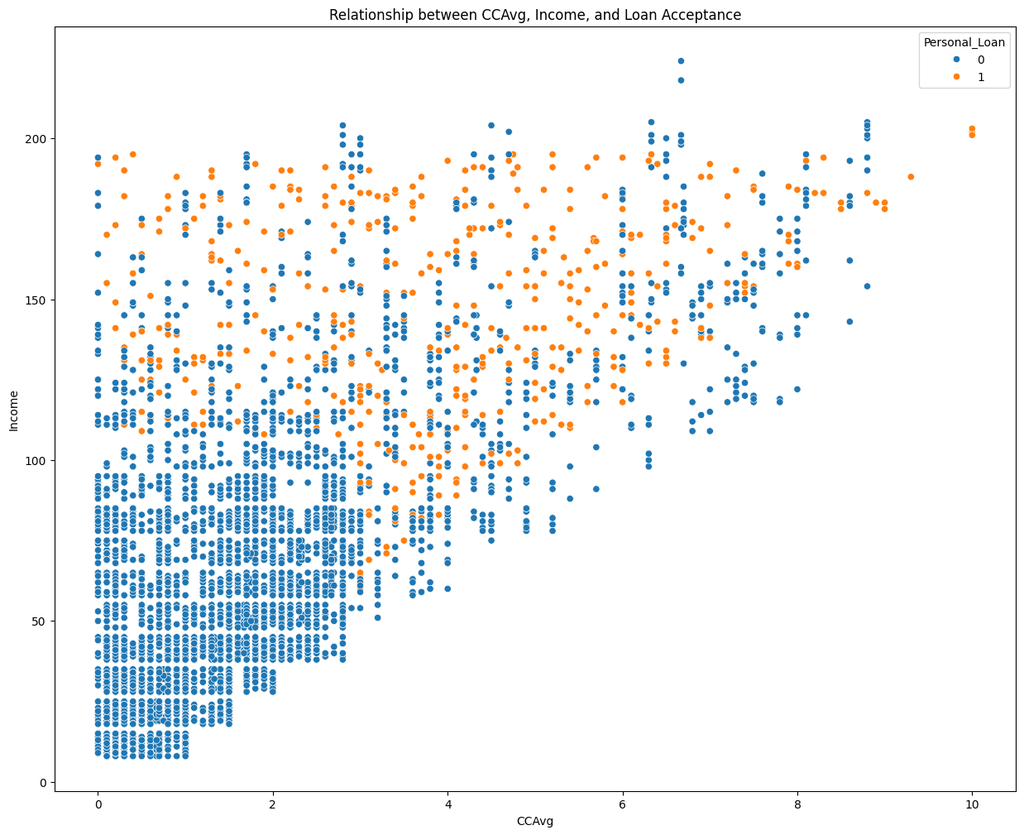

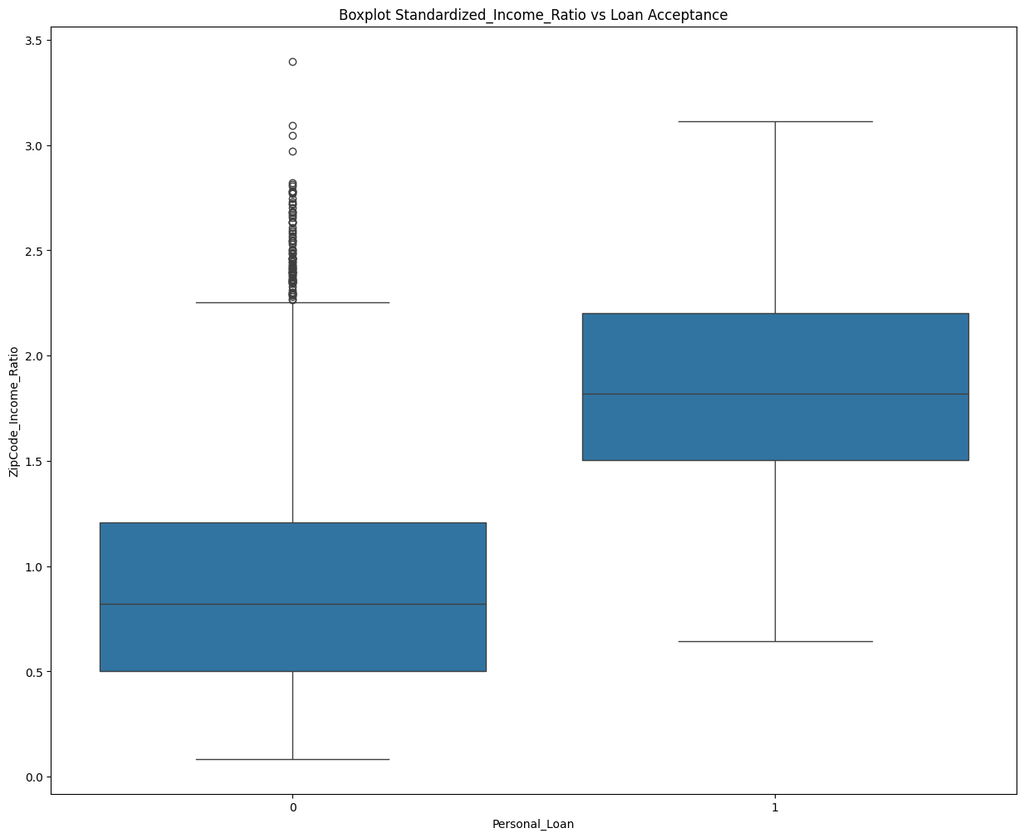

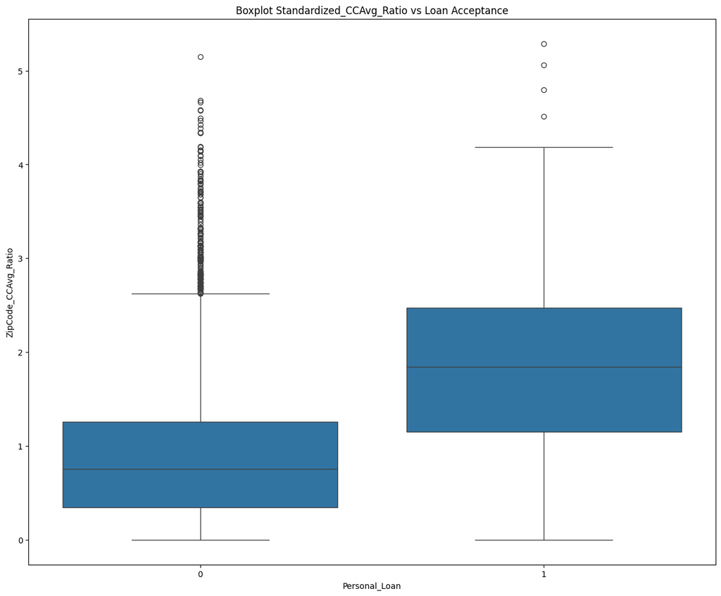

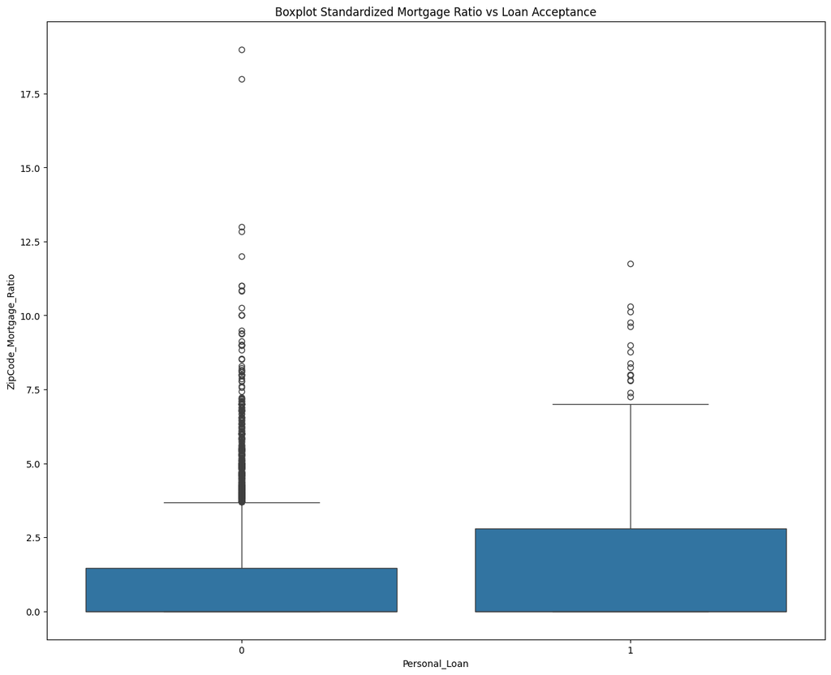

```python
# Ensure numerical columns are appropriately typed
df['Income'] = df['Income'].astype(float)
df['CCAvg'] = df['CCAvg'].astype(float)
df['Mortgage'] = df['Mortgage'].astype(float)

##Feature Engineering- Create standardized columns for income, mortgage, and credit card spend measuring the spread between zipcode income, CCAvg, and Mortgage to the overall average of the dataset for that variable##
df['ZipCode_Income_Ratio'] = df.groupby('ZIPCode')['Income'].transform(lambda x: x/x.mean())
df['ZipCode_CCAvg_Ratio'] = df.groupby('ZIPCode')['CCAvg'].transform(lambda x: x/x.mean())
df['ZipCode_Mortgage_Ratio'] = df.groupby('ZIPCode')['Mortgage'].transform(lambda x: x/x.mean())

print(df.head())

print(df.info())


print(df.isnull().sum())

##All missing values in the original dataset are now treated, but we observe some new missing values were created when we made the new feature columns##

##Fill missing values with zeros- in this context, they truly represent zero values##
df['ZipCode_Income_Ratio'].fillna(0, inplace=True)
df['ZipCode_CCAvg_Ratio'].fillna(0, inplace=True)
df['ZipCode_Mortgage_Ratio'].fillna(0, inplace=True)

##We validate that all the missing values are fully filled##

##Feature Engineering was already completed to add a column for the standardized ratios##

##Analyze relationship between CCAvg and Income further##
plt.figure(figsize=(15,12));
plt.title('Relationship between CCAvg, Income, and Loan Acceptance')
sns.scatterplot(data=df, x='CCAvg', y='Income', hue='Personal_Loan');


##Analyze our new features more fully through boxplots##
##Income Ratio vs Acceptance
plt.figure(figsize=(15,12));
plt.title('Boxplot Standardized_Income_Ratio vs Loan Acceptance')
sns.boxplot(data=df, x='Personal_Loan', y= 'ZipCode_Income_Ratio');

##CCAvg Ratio vs Acceptance##
plt.figure(figsize=(15,12));
plt.title('Boxplot Standardized_CCAvg_Ratio vs Loan Acceptance')
sns.boxplot(data=df, x='Personal_Loan', y='ZipCode_CCAvg_Ratio');

##Mortgage Ratio vs Acceptance#
plt.figure(figsize=(15,12));
plt.title('Boxplot Standardized Mortgage Ratio vs Loan Acceptance')
sns.boxplot(data=df, x='Personal_Loan', y='ZipCode_Mortgage_Ratio');
```

This aligns with our previous observations that there appears to be a cutoff of around ~$100k where loan acceptances are overwhelmingly concentrated.

- We also observe that ~75% of rejections from customers occur when a customers Credit Card spend to the average spending across the dataset is <~1.25x. This might well be highly effective feature we can add in our model capturing overall trends in Credit Card spending on a relative basis.

Some Model building approaches worhy of consideration include the following:

1. Classification/Decision Tree- Predicting a label of yes vs no using a sample of training and testing data. We are concerned about whether the algorithm does a good job of distinguishing both groups.

## Model Building

```
  Age  Experience  Income Family  CCAvg  Education  Mortgage  Personal_Loan  \
0  25           1    49.0      4    1.6          1       0.0              0
1  45          19    34.0      3    1.5          1       0.0              0
2  39          15    11.0      1    1.0          1       0.0              0
3  35           9   100.0      1    2.7          2       0.0              0
4  35           8    45.0      4    1.0          2       0.0              0

  Securities_Account CD_Account Online CreditCard  ZipCode_Income_Ratio  \
0                  1          0      0          0              0.566081
1                  1          0      0          0              0.408889
2                  0          0      0          0              0.149293
3                  0          0      0          0              1.806240
4                  0          0      0          1              0.685204

   ZipCode_CCAvg_Ratio  ZipCode_Mortgage_Ratio
0             0.819672                     0.0
1             0.685885                     0.0
2             0.531129                     0.0
3             2.275862                     0.0
4             0.645161                     0.0
  Age  Experience  Income Family  CCAvg  Education  Mortgage  Personal_Loan  \
0  25           1    49.0      4    1.6          1       0.0              0
1  45          19    34.0      3    1.5          1       0.0              0
2  39          15    11.0      1    1.0          1       0.0              0
3  35           9   100.0      1    2.7          2       0.0              0
4  35           8    45.0      4    1.0          2       0.0              0

  Securities_Account CD_Account Online CreditCard  ZipCode_Income_Ratio  \
0                  1          0      0          0              0.566081
1                  1          0      0          0              0.408889
2                  0          0      0          0              0.149293
3                  0          0      0          0              1.806240
4                  0          0      0          1              0.685204

   ZipCode_CCAvg_Ratio  ZipCode_Mortgage_Ratio
0             0.819672                     0.0
1             0.685885                     0.0
2             0.531129                     0.0
3             2.275862                     0.0
4             0.645161                     0.0
Training Columns: Index(['Age', 'Experience', 'Income', 'Family', 'CCAvg', 'Education',
       'Mortgage', 'Securities_Account', 'CD_Account', 'Online', 'CreditCard',
       'ZipCode_Income_Ratio', 'ZipCode_CCAvg_Ratio',
       'ZipCode_Mortgage_Ratio'],
      dtype='object')
Index(['Age', 'Experience', 'Income', 'Family', 'CCAvg', 'Education',
       'Mortgage', 'Personal_Loan', 'Securities_Account', 'CD_Account',
       'Online', 'CreditCard', 'ZipCode_Income_Ratio', 'ZipCode_CCAvg_Ratio',
       'ZipCode_Mortgage_Ratio'],
      dtype='object')
# of Rows in training dataset: 4000
# of Rows in test dataset: 1000
```

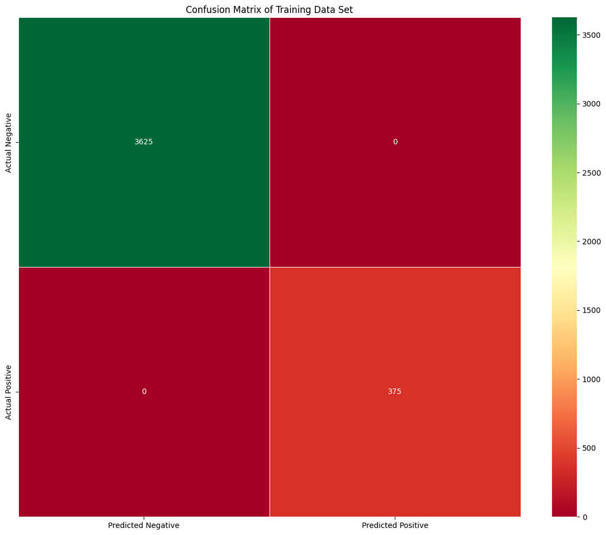

```python
##Start initial test run- use a classification algorithm for the model building process##

##Drop the id and zipcode columns##
df = df.drop(['ID', 'ZIPCode'], axis=1)



##Drop id and zip code columns##
print(df.head())

##Drop id and zipcode from the input columns##

print(df.head())


##Split the dataset into testing and training datasets##
X = df.drop('Personal_Loan', axis=1)
y = df['Personal_Loan']

print("Training Columns:", X.columns)


print(df.columns)


##Split the dataset into training and test dataset, use 20% of the original dataset for testing, and set 'random_state'= 42 for reproducibility##
X_train, X_test, y_train, y_test = train_test_split(X, y, test_size=0.2, random_state=42)

##Display the breakout of testing and training dataset based on the number of rows##
print("# of Rows in training dataset:", X_train.shape[0])
print("# of Rows in test dataset:", X_test.shape[0])


"""Before applying pre-pruning to the tree complete one iteration without it"""
##Initialize decision tree classifier##

decision_tree1 = DecisionTreeClassifier(criterion='gini',  random_state=42)


##Fit the model to the training dataset##
fitted_tree = decision_tree1.fit(X_train, y_train)

##Create predicted values##
training_predictions = fitted_tree.predict(X_train)

testing_predictions = fitted_tree.predict(X_test)

###Create model evaluation##

##Graph the confusion matrix of the results for the training set##
plt.figure(figsize=(15,12));
plt.title('Confusion Matrix of Training Data Set')

#Create the confusion matrix#
train_confusion_matrix = confusion_matrix(training_predictions, y_train)
#Build a heatmap of the data, pass the desired labels to the heatmap() function#
sns.heatmap(data = train_confusion_matrix, annot=True, cmap='RdYlGn', fmt='d', linewidths=0.5, xticklabels=['Predicted Negative', 'Predicted Positive'], yticklabels=['Actual Negative', 'Actual Positive']);
```

### Model Evaluation Criterion

Model Evaluation Criteria:

1. Balance between Recall and Precision (F1-Score)
2. Maintain strong accuracy, recall, precision, and F-1 Scores greater than 0.9 on each criteria.
3. Choose the model that provides the best balanced outcome on the TEST SET

### Model Building

```
Train:                    precision    recall  f1-score   support

Non-loan Customer       1.00      1.00      1.00      3625
    Loan Customer       1.00      1.00      1.00       375

         accuracy                           1.00      4000
        macro avg       1.00      1.00      1.00      4000
     weighted avg       1.00      1.00      1.00      4000

Test:                    precision    recall  f1-score   support

Non-loan Customer       0.99      0.99      0.99       895
    Loan Customer       0.94      0.91      0.93       105

         accuracy                           0.98      1000
        macro avg       0.97      0.95      0.96      1000
     weighted avg       0.98      0.98      0.98      1000
```

[figure not shown]

```python
##Graph the confusion matrix of the results for the testing set##
plt.figure(figsize=(15,12));
plt.title('Confusion Matrix of Test Data Set')
test_confusion_matrix = confusion_matrix(testing_predictions, y_test)
#Build a heatmap of the test data, passing the desired labels to the heatmap() function/method#
sns.heatmap(data = test_confusion_matrix, annot=True, cmap='RdYlGn', fmt='d', linewidths=0.5, xticklabels=['Predicted Negative', 'Predicted Positive'], yticklabels=['Actual Negative', 'Actual Positive']);

##Output Model Evaluation Metrics##
##Calculate Model performance metrics##
## Generate the classification report for the training data set##
train_class_report = classification_report(training_predictions, y_train)
#print("Training Dataset Evaluation:", train_class_report)

#Generate the classification report for the testing data set##
test_class_report = classification_report(testing_predictions, y_test)
#print("Testing Dataset Evaluation:", test_class_report)

##Train Predictions##
#print(training_predictions)
#print(y_train)

##Testing Predictions##

# Generate the report for the training performance #
train_report = classification_report(y_train, training_predictions, target_names=["Non-loan Customer", "Loan Customer"])

print("Train:", train_report)

#Generate the report for the testing performance #
test_report = classification_report(y_test, testing_predictions, target_names=["Non-loan Customer", "Loan Customer"])

print("Test:", test_report)
```

This model could be improved in 2 ways-

1. Pre-pruning the decision tree by preventing it from growing to its full depth (thus not allowing it to overfit)
2. Post-pruning where we build the decision tree then apply cost complexity pruning techniques to trim/remove branches that are not contributing to our predictive power.

## Model Performance Improvement

```python
#Extract Feature Importances#_

print(type(testing_predictions))
print(type(y_test))

print(type(decision_tree1))

##Re-assign our first model to a simpler name##
dt_model1 = decision_tree1

print(type(dt_model1))

# Extract feature importances from the trained decision tree model
importances = dt_model1.feature_importances_
#print(importances)
features = X_train.columns
feature_importance_df = pd.DataFrame({'Feature': features, 'Importance': importances}).sort_values(by='Importance', ascending=False).reset_index()
print(feature_importance_df)
```

```
<class 'numpy.ndarray'>
<class 'pandas.core.series.Series'>
<class 'sklearn.tree._classes.DecisionTreeClassifier'>
<class 'sklearn.tree._classes.DecisionTreeClassifier'>
    index                 Feature  Importance
0       5               Education    0.370961
1       2                  Income    0.296530
2       3                  Family    0.168570
3       4                   CCAvg    0.052076
4       0                     Age    0.024200
5      11    ZipCode_Income_Ratio    0.022100
6       1              Experience    0.015782
7       8              CD_Account    0.014139
8       9                  Online    0.013792
9      13  ZipCode_Mortgage_Ratio    0.008659
10     12     ZipCode_CCAvg_Ratio    0.007661
11      6                Mortgage    0.003568
12     10              CreditCard    0.001962
13      7      Securities_Account    0.000000
```

## Model Performance Comparison and Final Model Selection

```
Starting Maximum Depth: 13
Train:                    precision    recall  f1-score   support

Non-loan Customer       1.00      0.99      0.99      3648
    Loan Customer       0.90      0.96      0.93       352

         accuracy                           0.99      4000
        macro avg       0.95      0.98      0.96      4000
     weighted avg       0.99      0.99      0.99      4000

Test:                    precision    recall  f1-score   support

Non-loan Customer       1.00      0.99      0.99       900
    Loan Customer       0.91      0.96      0.94       100

         accuracy                           0.99      1000
        macro avg       0.95      0.97      0.96      1000
     weighted avg       0.99      0.99      0.99      1000
```

[figure not shown]

[figure not shown]

```python
###Apply pre-pruning to decision tree results##

starting_max_depth = len(X_train.columns) - 1

print("Starting Maximum Depth:", starting_max_depth)

#Initialize decision tree classifier #2 ##

##Applied pre-pruning decision tree parameters##
##Limit the maximum depth of the tree to the number of columns in the dataset minus 1##

##Require a minimum of 30 samples in a leaf to split it##
decision_tree2 = DecisionTreeClassifier(criterion='gini', splitter='best', max_depth= starting_max_depth, min_samples_split=30)

##Apply train test split on the dataset again ##
X_train, X_test, y_train, y_test = train_test_split(X, y, test_size=0.2, random_state=42)


##Fit the model to the decision tree##
fitted_dtree2 = decision_tree2.fit(X_train, y_train)

#Create predictions/predicted labels/values##
training_predictions2 = fitted_dtree2.predict(X_train)
testing_predictions2 = fitted_dtree2.predict(X_test)

##Build a confusion matrix with our results##
confusion_matrix_train2 = confusion_matrix(training_predictions2, y_train)
confusion_matrix_test2 = confusion_matrix(testing_predictions2, y_test)


##Plot the training results##
plt.figure(figsize=(15,12));
plt.title('Confusion Matrix of Training Data Set (Pre-Pruned)')
sns.heatmap(data = confusion_matrix_train2, annot=True, cmap='RdYlGn', fmt='d', linewidths=0.5, xticklabels=['Predicted Negative', 'Predicted Positive'], yticklabels=['Actual Negative', 'Actual Positive']);

##Plot the testing results##
plt.figure(figsize=(15,12));
plt.title('Confusion Matrix of Testing Data Set (Pre-Pruned)')
sns.heatmap(data = confusion_matrix_test2, annot=True, cmap='RdYlGn', fmt='d', linewidths=0.5, xticklabels=['Predicted Negative', 'Predicted Positive'], yticklabels=['Actual Negative', 'Actual Positive']);

##Finally obtain the classification reports of our model##
train_class_report2 = classification_report(training_predictions2, y_train, target_names=["Non-loan Customer", "Loan Customer"])
test_class_report2 = classification_report(testing_predictions2, y_test, target_names=["Non-loan Customer", "Loan Customer"])

print("Train:", train_class_report2)
print("Test:", test_class_report2)
```

```
CCP Alphas: [0.00000000e+00 8.68421053e-05 2.03588517e-04 2.64338624e-04
 2.76384535e-04 3.78787879e-04 4.54002193e-04 6.29157428e-04
 6.76279902e-04 7.69981334e-04 8.53838962e-04 8.80208333e-04
 1.22632576e-03 1.36278297e-03 2.40248205e-03 3.19707854e-03
 5.75820271e-03 2.61657088e-02 5.21493015e-02]
Impurities: [0.01588316 0.01597    0.01658077 0.01737378 0.01765017 0.01802896
 0.01848296 0.01974127 0.02041755 0.02118754 0.02204137 0.02292158
 0.02537423 0.0280998  0.03050228 0.03369936 0.03945756 0.06562327
 0.16992188]
```

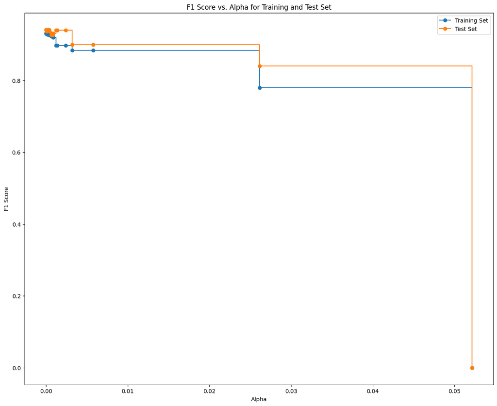

```python
##Final Step- we apply cost-complexity pruning to determine if there is a simplier model that might be easier to deploy and to validate the robustness of our existing approach##

##Calculate cost complexity parameters on our model##
post_pruned_model = decision_tree2.cost_complexity_pruning_path(X_train, y_train)

##Parse out the components from above##
ccp_alphas, impurities = post_pruned_model.ccp_alphas, post_pruned_model.impurities

print("CCP Alphas:", ccp_alphas)

print("Impurities:", impurities)

##We now want to observe CCP Alphas against impurity for both the training and test datasets##
train_f1_scores=[]
test_f1_scores=[]

for alpha in ccp_alphas:
  model = DecisionTreeClassifier(criterion='gini', splitter='best', max_depth=starting_max_depth, min_samples_split=30, ccp_alpha=alpha)
  model.fit(X_train, y_train)

  #Create training prediction##
  y_train_pred = model.predict(X_train)
  y_test_pred = model.predict(X_test)

  #Calculate F1 scores##
  train_f1_scores.append(f1_score(y_train, y_train_pred))
  test_f1_scores.append(f1_score(y_test, y_test_pred))


##Plot the tradeoff between Alpha and Impurities in the training dataset##
plt.figure(figsize= (15,12));

#Plot training set#
plt.plot(ccp_alphas, train_f1_scores, marker='o', label='Training Set', drawstyle="steps-post")
#Plot test set#
plt.plot(ccp_alphas, test_f1_scores, marker='o', label='Test Set', drawstyle="steps-post")
plt.xlabel("Alpha")
plt.ylabel("F1 Score")
plt.title("F1 Score vs. Alpha for Training and Test Set")
plt.legend()
plt.show()





#plt.figure(figsize=(10, 6))
#plt.plot(ccp_alphas, impurities, marker='o', drawstyle="steps-post")
#plt.xlabel("Alpha")
#plt.ylabel("Total Impurity")
#plt.title("Impurity vs. alpha for training set")
#plt.show()
```

```python
##Identify the optimal alpha value##
optimal_alpha = ccp_alphas[test_f1_scores.index(max(test_f1_scores))]
print(f"Optimal ccp_alpha: {optimal_alpha}")


##We identify the optimal alpha value is 0 which identicates pre-pruning the tree was very effective to capturing the key patterns in the data without overfitting and generalizes to new data well##
##This indicates that post-pruning is not needed to improve our results further##
```

```
Optimal ccp_alpha: 0.0
```

This indicates that our pre-pruned model is the optimal and ideal model, and that no cost complexity pruning is neccessary to improve the model's performance or generalizability.